# Mini introduction to R

2023-05-25

This is a mini introduction to how to use R. The goal is to learn the general aspects of how R works to use Seurat.

# Running basic commands

```r
1 + 1 # arithmetic operators
```

```
## [1] 2
```

```r
9 > 10 # logical operator for comparisons
```

```
## [1] FALSE
```

# Variables

Variables can be assigned using ‘<-’ or ‘=’

## Scalar

Used to save a single value

```r
a <- 1 + 0.02 # numeric
a
```

```
## [1] 1.02
```

## Vectors

Used to save multiple values of the same type in a 1-D array

```r
vectorNumbers <- c(1, 2, 4) # Create a numeric vector containing numbers
vectorNumbers
```

```
## [1] 1 2 4
```

```r
vectorStrings <- c("neuron", "glia") # Create a vector containing characteres
vectorStrings
```

```
## [1] "neuron" "glia"
```

## Matrix

Used to save multiple values of the same type in a 2-D array

```r
MatrixNum <- matrix(data = c(1,1,1,2,2,2,3,3,3,4,4,4), nrow = 3, ncol = 4) # Numeric matrix filled by column (3x4)
MatrixNum
```

```
##      [,1] [,2] [,3] [,4]
## [1,]    1    2    3    4
## [2,]    1    2    3    4
## [3,]    1    2    3    4
```

## Data frame

Used to save multiple values of the same size in a 2-D array

```r
DataFrame <- data.frame( numbers = c(1,2,3), region = c("cortex", "hippocampus", "spinal cord"),
              cells = c(1000, 30488, 2084))

DataFrame
```

```
##   numbers      region cells
## 1       1      cortex  1000
## 2       2 hippocampus 30488
## 3       3 spinal cord  2084
```

## List

Use to save different types of values of different sizes in a multidimensional array

```r
ListRandom <- list(DataFrame, MatrixNum, vectorStrings, vectorNumbers, a)
ListRandom
```

```
## [[1]]
##   numbers      region cells
## 1       1      cortex  1000
## 2       2 hippocampus 30488
## 3       3 spinal cord  2084
##
## [[2]]
##      [,1] [,2] [,3] [,4]
## [1,]    1    2    3    4
## [2,]    1    2    3    4
## [3,]    1    2    3    4
##
## [[3]]
## [1] "neuron" "glia"
##
## [[4]]
## [1] 1 2 4
##
## [[5]]
## [1] 1.02
```

# Functions

Functions are blocks of code grouped together to handle similar inputs and produce a specific output.

For example, we can calculate the mean of a numeric vector

```r
mean(c(90,4,5,.3))
```

```
## [1] 24.825
```

or sort it

```r
sort(c(90,4,5,.3))
```

```
## [1]  0.3  4.0  5.0 90.0
```

get dimensions

```r
DataFrame
```

```
##   numbers      region cells
## 1       1      cortex  1000
## 2       2 hippocampus 30488
## 3       3 spinal cord  2084
```

```r
dim(DataFrame)
```

```
## [1] 3 3
```

```r
rownames(DataFrame)
```

```
## [1] "1" "2" "3"
```

```r
colnames(DataFrame)
```

```
## [1] "numbers" "region"  "cells"
```

# Access variables

‘[]’ lets you access variables using indices

```r
vectorGenes <- c("Foxp2", "Spp1", "Sdk1", "Satb1", "Calb")
vectorGenes [3] # get element in the 3rd position
```

```
## [1] "Sdk1"
```

```r
vectorGenes [1:3] # get elements from 1st to 3rd position
```

```
## [1] "Foxp2" "Spp1"  "Sdk1"
```

```r
vectorGenes [c(2,5)] # get element in the 2nd and 5th positions
```

```
## [1] "Spp1" "Calb"
```

Accessing matrices

```r
MatrixNum <- matrix(data = c(1,1,1,2,2,2,3,3,3,4,4,4), nrow = 3, ncol = 4)
MatrixNum [, 1] # accessing all rows in the 1st column
```

```
## [1] 1 1 1
```

```r
MatrixNum [2, ] # accessing all columns in the 2nd row
```

```
## [1] 1 2 3 4
```

Accessing data frame

```r
DataFrame <- data.frame( numbers = c(1,2,3,4), region = c("cortex", "hippocampus", "spinal cord", "cortex"), cells = c(1000, 30488, 2084, 8888))

DataFrame$region #access elements in column "region"
```

```
## [1] "cortex"      "hippocampus" "spinal cord" "cortex"
```

```r
DataFrame$region [2] # access 2nd element in the column "region"
```

```
## [1] "hippocampus"
```

```r
DataFrame$region == "cortex" # logical indices that meet a condition
```

```
## [1]  TRUE FALSE FALSE  TRUE
```

```r
DataFrame [DataFrame$region == "cortex", ] # access rows that a meet condition
```

```
##   numbers region cells
## 1       1 cortex  1000
## 4       4 cortex  8888
```

# Importing Data

To analyze data in Seurat you will need to read gene expression data into R. The easiest way is to use the *read.table* function.

Here, we read a table which contains a header and each element is separated by a ‘,’.

```r
mydata <- read.table("c:/mydata.csv", header=TRUE, sep=",")
```

For variable formats, take a look at the *read.table* help.

```r
help("read.table")
```

```
## starting httpd help server ... done
```

# libraries

There are some variables type and function that are specific for some Libraries. You can install them in the “packages” section. Once installed, libraries need to be re-load every time you reset R.

```r
library("ggplot2") #load library "ggplot2"
data(PlantGrowth) # load sample data
head (PlantGrowth) # take a look at the first element of the data set
```

```
##   weight group
## 1   4.17  ctrl
## 2   5.58  ctrl
## 3   5.18  ctrl
## 4   6.11  ctrl
## 5   4.50  ctrl
## 6   4.61  ctrl
```

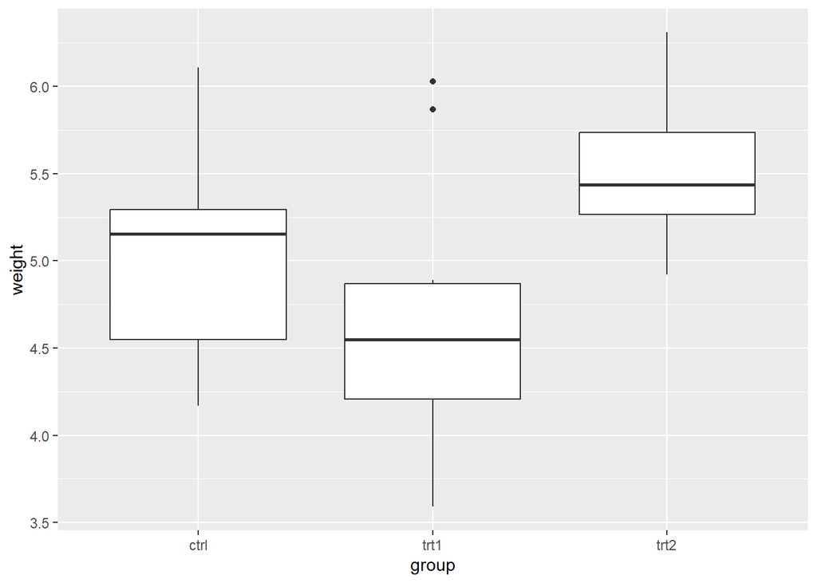

```r
ggplot(data = PlantGrowth, aes(x = group, y = weight)) + geom_boxplot()
```